# Regresión con variables contiuas y categóricas

Los regresores

07/11/2019

En un laboratorio clínico se llevó a cabo un experimento para valorar cómo el nivel de temperatura y la naturaleza ácida de cierto caldo de cultivo influía en el crecimiento de una población de bacterias.

Más específicamente, se consideraron dos factores: temperatura, a tres distintos niveles: 30°C, 60°C y 90°C; dos tipos de caldo de cultivo: básico (B) y ácido (A), cada uno de ellos a dos niveles de concentraciones:baja (L) y alta (H).Como respuesta se consideró como se modificaba una población inicial de 1000 bacterias después de 48 horas de en el ambiente controlado.

### **Análisis de los resultados del experimento**

Con el objetivo de analizar el comportamiento que se observa en el número de bacterias, dependiendo de la temperatura, se analizó el diagrama de caja y brazos de la Figura 1, en la cual se observa que el mínimo crecimiento de bacterias entre temperaturas se presentó a 90°C, mientras que el mayor crecimiento se observó en los 60°C. De lo que se concluye que la temperatura de 60°C favorece al crecimiento de las bacterias y, por el contrario, a 90°C no hay un crecimiento tan elevado.

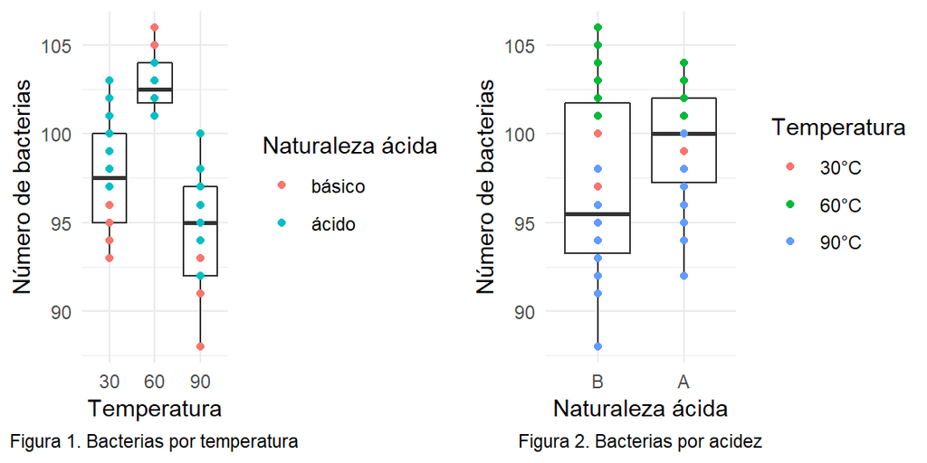

Por otro lado, la Figura 2 analiza el comportamiento que tiene el número de bacterias, dependiendo de su naturaleza ácida. Se observa que tanto el mínimo como el máximo de bacterias se presentan en los cultivos básicos, es decir, el rango de este tipo de cultivo resultó mayor que el del cultivo ácido. Es importante notar que la mediana en los caldos de cultivo ácido fue mayor que la mediana en los caldos de cultivo básico.

Para una descripción más detallada de los datos es relevante analizar la Figura 3, en la cual es claro el comportamiento de los tipos de caldo de cultivo.

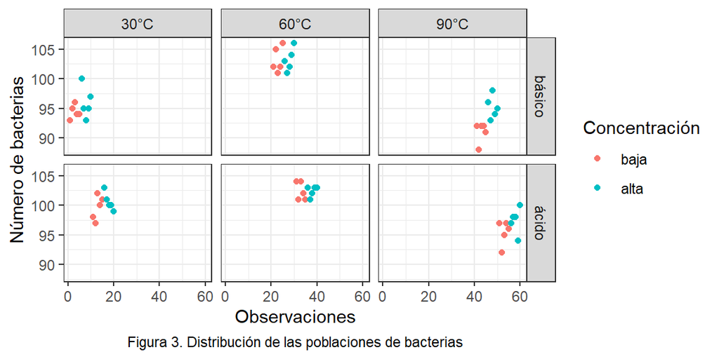

Para el caldo de cultivo básico la temperatura a la que existe mayor crecimiento de bacterias es 60°C, mientras que para los 30°C y 90°C el crecimiento es similar, aunque a 90°C se registran los crecimientos más bajos.

Por su parte, en el caldo de cultivo ácido no es tan evidente que la temperatura de 60°C sea la que más favorezca el crecimiento de bacterias, el cual fue similar al comportamiento a 30°C, sin embargo, sigue siendo la que predomina. De igual manera, a 90°C se registra un menor crecimiento.

Las concentraciones resultan en un número de bacterias parecido. En lo que se diferencian es que las concentraciones bajas tienen mayor variabilidad (Figura 4).

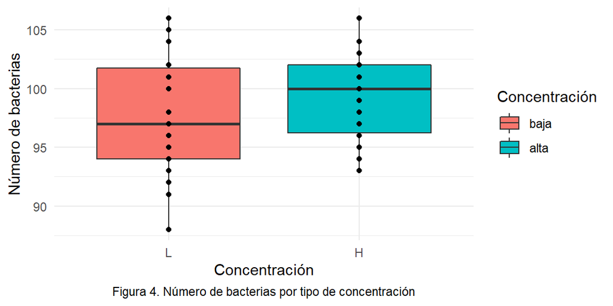

A continuación, se detalla el comportamiento de la concentración, para cada nivel de temperatura, tomando en cuenta el caldo de cultivo.

##### **Temperatura 30°C**

En la Figura 5 se observa hay un número similar de bacterias entre ambas concentraciones, pero en el caldo de cultivo ácido hay más bacterias que en el caldo de cultivo básico. Aunque en este caso la concentración no tiene mucha influencia en el número de bacterias.

##### **Temperatura 90°**

El tipo de concentración tiene un papel más importante que en los casos anteriores; cuando la concentración es alta hay mayor número de bacterias que cuando la concentración es baja. Además, el tipo de caldo de cultivo también es importante en esta temperatura, dado que los cultivos básicos presentan menor número de bacterias que los cultivos ácidos (Figura 7).

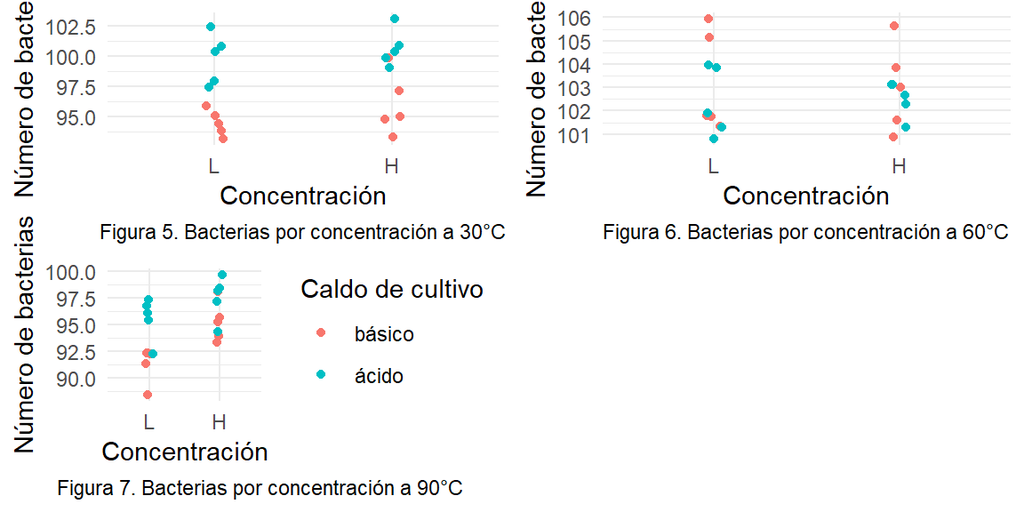

Después de hacer la descripción gráfica de los resultados del experimento podemos concluir que el nivel medio de temperatura sí tiene un efecto sobre el número de bacterias. En particular, cuando la temperatura es de 60°C el número de bacterias promedio es el mayor como se puede ver en el Cuadro 1.

Cuadro 1. Número de bacterias promedio por temperatura

| Temperatura | Media |
| --- | --- |
| 30 | 97.65 |
| 60 | 102.80 |
| 90 | 94.75 |

Además, el tipo de cultivo también tiene un efecto sobre el número de bacterias. En general, en el cultivo ácido el número de bacterias promedio es mayor que en el cultivo básico, así como la mediana, la cual se observa en el Cuadro 2. El único caso cuando no se cumple es cuando la temperatura es de 60°C ya que ocurre todo lo contrario.

Cuadro 2. Número de bacterias promedio y mediana por caldo de cultivo

| Caldo de cultivo | Media | Mediana |
| --- | --- | --- |
| B | 97.16667 | 95.5 |
| A | 99.63333 | 100.0 |

##### **Interacción entre los factores de temperatura y caldo de cultivo**

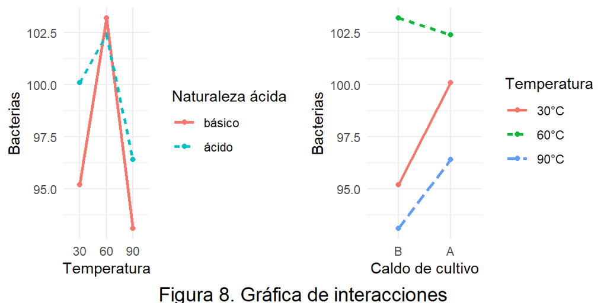

Se confirma que entre la temperatura y el tipo de cultivo hay interacción, dado que la relación entre ambos no es del todo consistente, puesto que de 30°C y 60°C la población de bacterias aumenta, esta disminuye a 90°C; sin embargo en los cultivos ácidos existe, en promedio, un mayor número de bacterias en las temperaturas de 30°C y 90°C, mientras que a 60°C hay un menor número, en promedio, que en los cultivos básicos.

Entonces, seleccionar un modelo con interacción es lo más adecuado.

Primero, se elige un modelo donde haya interacción entre la temperatura y el tipo de caldo de cultivo; este está dado por:

$$NumBacterias = \mu + Temperatura + Acidez + Temperatura:Acidez + \epsilon$$

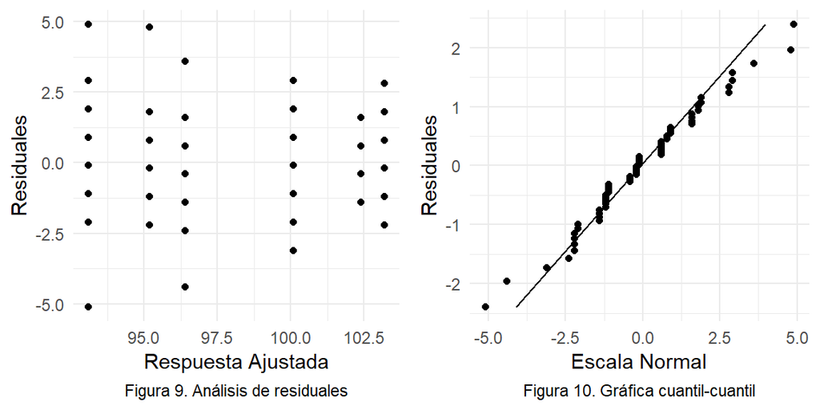

Ahora, considerando la significia de los niveles de concentración tenemos el modelo:

$$NumBacterias = \mu + Temperatura + Acidez + Concentracion + Temperatura:Acidez + \epsilon$$

Se tiene $R^2 = 0.8143$, lo que significa que la variabilidad del número de bacterias se justifica un $81.43\%$ con el nuevo modelo. A través del análisis de varianza se obtiene un valor p, del estadítico F, de $0.005024$ para la concentración.

Al gráficar la respuesta ajustada y los residuales (Figura 11) no es posible encontrar ningún patrón, sin embargo en la Figura 12 ya no es posibles asegurar que los residuales siguen una distribución normal como en la gráfica cuantil-cuantil del modelo anterior (Figura 10).

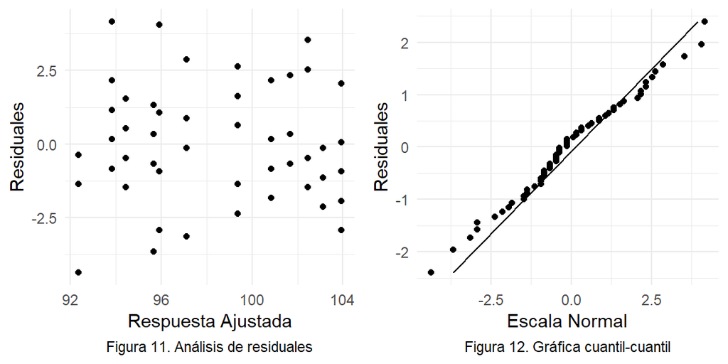

Así, se puede decir que ambos modelos son válidos, sin embargo el último tiene un mejor ajuste.

### **Conclusiones**

En primer lugar de la descripción gráfica de los datos se concluye que el nivel medio de temperatura sí tiene efecto sobre el número de bacterias,de igual forma el efecto que tiene el tipo de cultivo es importante.Por otra parte se observó que existe interacción entre las variables temperatura y el tipo de caldo de cultivo ya que la relación entre ellas no fue consistente.

En busca de un mejor modelo se propone uno tal que considere la variable de concentración además de las variables consideradas en el primer modelo. El cual explica el 81.43% de la variabilidad del número de bacterias, en cuanto a la concentración se obtuvó un valor p de 0.005024 por lo que se concluye que sí ayuda a explicar el crecimiento de las bacterias aunque no tanto como lo hacen la temperatura y el tipo de caldo de cultivo.

Finalmete en la gráfica de residuales no se observan patrones en ninguno de los modelos, sin embargo el en primer modelo es más evidente que los residuales se asemejan a una distribución normal.A pesar de este resultado concluimos que el segundo modelo es el que mejor ajusta, ya que aunque no es tan evidente la normalidad de los datos es aceptable, además de que explica un mayor porcentaje de la varuablidad del número de bacterias y la variable que se incluye en el segundo modelo es significativa.

##### **Apéndice A**

Número de bacterias explicado por temperatura y naturaleza ácida (efectos lineales e interacciones solo entre las variables):

$$NumBacterias = \mu + Temperatura + Acidez + Temperatura:Acidez + \epsilon$$

```
##
## Call:
## lm(formula = Nbact ~ Temp * Acid, data = datos)
##
## Residuals:
##    Min     1Q Median     3Q    Max
## -5.100 -1.200 -0.150  1.075  4.900
##
## Coefficients:
##              Estimate Std. Error t value Pr(>|t|)
## (Intercept)   95.2000     0.6552 145.304  < 2e-16 ***
## Temp60         8.0000     0.9266   8.634 9.47e-12 ***
## Temp90        -2.1000     0.9266  -2.266   0.0275 *
## AcidA          4.9000     0.9266   5.288 2.29e-06 ***
## Temp60:AcidA  -5.7000     1.3104  -4.350 6.08e-05 ***
## Temp90:AcidA  -1.6000     1.3104  -1.221   0.2274
## ---
## Signif. codes:  0 '***' 0.001 '**' 0.01 '*' 0.05 '.' 0.1 ' ' 1
##
## Residual standard error: 2.072 on 54 degrees of freedom
## Multiple R-squared:  0.7843, Adjusted R-squared:  0.7643
## F-statistic: 39.26 on 5 and 54 DF,  p-value: < 2.2e-16
```

```
## Analysis of Variance Table
##
## Response: Nbact
##           Df Sum Sq Mean Sq F value    Pr(>F)
## Temp       2 664.90  332.45  77.447 < 2.2e-16 ***
## Acid       1  91.27   91.27  21.261 2.497e-05 ***
## Temp:Acid  2  86.43   43.22  10.068 0.0001923 ***
## Residuals 54 231.80    4.29
## ---
## Signif. codes:  0 '***' 0.001 '**' 0.01 '*' 0.05 '.' 0.1 ' ' 1
```

##### **Apéndice B**

Número de bacterias explicado por temperatura, naturaleza ácida y concentración (efectos lineales e interacciones solo entre temperatura y acidez):

$$NumBacterias = \mu + Temperatura + Acidez + Concentracion + Temperatura:Acidez + \epsilon$$

```
##
## Call:
## lm(formula = Nbact ~ Temp * Acid + Conc, data = datos)
##
## Residuals:
##     Min      1Q  Median      3Q     Max
## -4.3667 -0.9333 -0.2500  1.2083  4.1667
##
## Coefficients:
##              Estimate Std. Error t value Pr(>|t|)
## (Intercept)   94.4667     0.6627 142.540  < 2e-16 ***
## Temp60         8.0000     0.8677   9.219 1.33e-12 ***
## Temp90        -2.1000     0.8677  -2.420  0.01898 *
## AcidA          4.9000     0.8677   5.647 6.56e-07 ***
## ConcH          1.4667     0.5010   2.928  0.00502 **
## Temp60:AcidA  -5.7000     1.2272  -4.645 2.29e-05 ***
## Temp90:AcidA  -1.6000     1.2272  -1.304  0.19793
## ---
## Signif. codes:  0 '***' 0.001 '**' 0.01 '*' 0.05 '.' 0.1 ' ' 1
##
## Residual standard error: 1.94 on 53 degrees of freedom
## Multiple R-squared:  0.8143, Adjusted R-squared:  0.7933
## F-statistic: 38.73 on 6 and 53 DF,  p-value: < 2.2e-16
```

```
## Analysis of Variance Table
##
## Response: Nbact
##           Df Sum Sq Mean Sq F value    Pr(>F)
## Temp       2 664.90  332.45 88.3053 < 2.2e-16 ***
## Acid       1  91.27   91.27 24.2422 8.683e-06 ***
## Conc       1  32.27   32.27  8.5707  0.005024 **
## Temp:Acid  2  86.43   43.22 11.4792 7.212e-05 ***
## Residuals 53 199.53    3.76
## ---
## Signif. codes:  0 '***' 0.001 '**' 0.01 '*' 0.05 '.' 0.1 ' ' 1
```